# Chapter1: Exploratory Data Analysis

#### State vs Default Rate

Delaware appears to have the highest default rate of about 75%

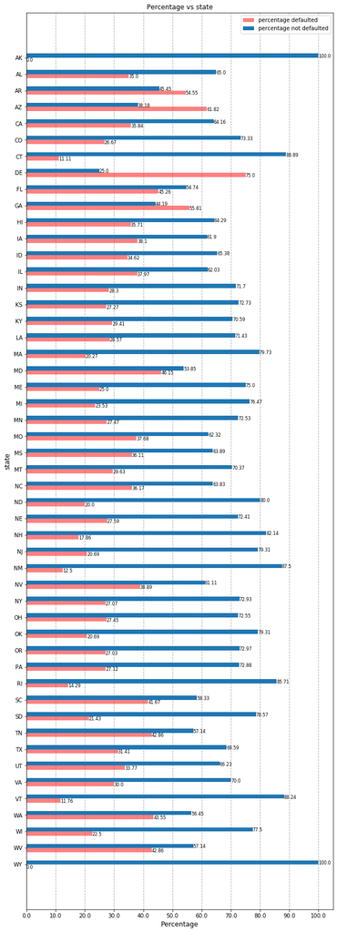

```python
bins0 = data['state'].unique()
plot_discrete_histogram(data,'state',bins0,(10,30))
```

```python
data.loc[(data['state']=='MT')]['default_status'].sum()
```

```
8
```

#### Industry vs Default Rate

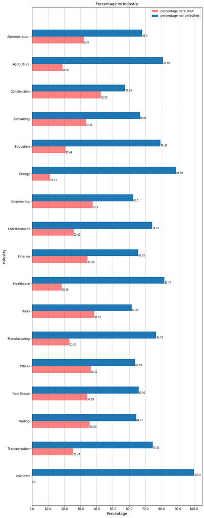

```python
bins0 = data['industry'].unique()
plot_discrete_histogram(data,'industry',bins0,(10,30))
```

```python
data.loc[(data['industry']=='Agriculture')]['default_status'].sum()
```

```
11
```

#### Month vs Default Rate

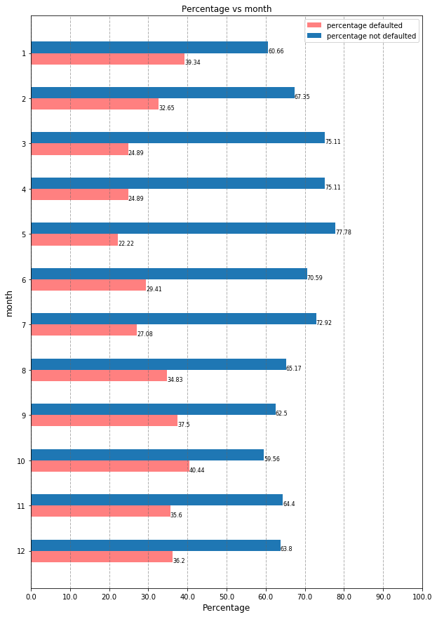

```python
bins0 = data['month'].unique()
plot_discrete_histogram(data,'month',bins0,(10,15))
```

```python
data.loc[(data['month']==6)]['default_status'].sum()
```

```
40
```

#### Year vs. Default Rate

Default Rates are significantly higher in 2009 as compared to 2010. This may be due to the ongoing Global Financial Crisis

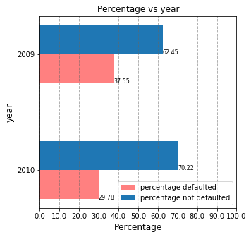

```python
bins0 = data['year'].unique()
plot_discrete_histogram(data,'year',bins0,(5,5))
```

```python
data.loc[(data['year']==2009)]['default_status'].sum()
```

```
279
```

#### Other Loans Vs. Default Rate

Surprisingly, people having other loans have lower default rates than people not having other loans. This may be due to the higher due diligence undertaken on people with more than 1 loan

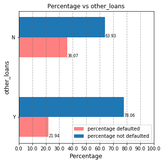

```python
bins0 = data['other_loans'].unique()
plot_discrete_histogram(data,'other_loans',bins0,(5,5))
```

# Chapter2: Feature Engineering, Model Training & Tuning

#### Compute State Default Rate

```python
data['ones'] = np.ones(data.shape[0])
data_st = data.groupby(['state']).agg({'default_status':'sum','ones':'sum'})
data_st['state_default_rate'] = data_st['default_status']/data_st['ones']
data_st = data_st.reset_index()[['state','state_default_rate']]
data_st.to_csv('state_default_rate.csv')
data = data.merge(data_st,how = 'left', on = 'state')
```

#### Compute Industry Default Rate

```python
data_id = data.groupby(['industry']).agg({'default_status':'sum','ones':'sum'})
data_id['industry_default_rate'] = data_id['default_status']/data_id['ones']
data_id = data_id.reset_index()[['industry','industry_default_rate']]
data_id.to_csv('industry_default_rate.csv')
data = data.merge(data_id,how = 'left', on = 'industry')
```

#### Select Features

- The Feature importance for the categorical variable month was seen to be very low. Thus it was dropped.
- There is a very high correlation between loan amount and insured_amount. Thus insured_amount is dropped.

```python
data[['loan_amount','insured_amount','employee_count','term','state_default_rate','industry_default_rate']].corr()
```

|  | loan_amount | insured_amount | employee_count | term | state_default_rate | industry_default_rate |
| --- | --- | --- | --- | --- | --- | --- |
| loan_amount | 1.000000 | 0.949696 | 0.236585 | 0.510284 | -0.014164 | -0.029362 |
| insured_amount | 0.949696 | 1.000000 | 0.217003 | 0.560795 | 0.002117 | -0.032407 |
| employee_count | 0.236585 | 0.217003 | 1.000000 | 0.085634 | -0.040689 | -0.049203 |
| term | 0.510284 | 0.560795 | 0.085634 | 1.000000 | 0.051510 | -0.021041 |
| state_default_rate | -0.014164 | 0.002117 | -0.040689 | 0.051510 | 1.000000 | 0.021441 |
| industry_default_rate | -0.029362 | -0.032407 | -0.049203 | -0.021041 | 0.021441 | 1.000000 |

```python
feature_list = [ \
                'term',
                'employee_count',
                'loan_amount',
               # 'insured_amount',
                'year',
                #'month',
                'state_default_rate',
                'industry_default_rate',
                'other_loans',
                'default_status'
               ]
data2 = data[feature_list]
```

```python
data2 = pd.get_dummies(data2,columns=['other_loans',
                                    #  'month',
                                      'year'])

df_y = data2['default_status']
df_x = data2.drop('default_status',axis = 1)
```

## Random Forest Hyperparameter Tuning

```python
def random_forest_randomsearch(df_x,df_y):
    from sklearn.model_selection import RandomizedSearchCV
    clf = RandomForestClassifier(random_state=42,oob_score = True)
    df_train2_x, df_test2_x, df_train2_y, df_test2_y = train_test_split(df_x, df_y,
                                                                        test_size=0.3, random_state=42,shuffle =True)

    param_grid =    {
    'n_estimators': range(30,70),
    'max_features': ['sqrt'],
    'max_depth' : range(1,10),
    'min_samples_leaf':range(1,5),
    'min_samples_split':range(2,7),
    'criterion' :['entropy']
    }


    CV_rfc = RandomizedSearchCV(estimator=clf, param_distributions=param_grid, cv= 5,n_jobs = 1,
                                n_iter = 20,verbose = 0,scoring = 'accuracy')
    CV_rfc.fit(df_train2_x,df_train2_y)
    results = CV_rfc.cv_results_
    CV_rfc_best_params = CV_rfc.best_params_
    CV_rfc_best_estimator = CV_rfc.best_estimator_
    return CV_rfc_best_estimator,CV_rfc_best_params,results
```

```python
import pickle

rf_model,params_rf,results = random_forest_randomsearch(df_x,df_y)
model_name = 'rf_model.sav'
pickle.dump(rf_model, open(model_name, 'wb'))
yhat = rf_model.predict(df_x)
probs = rf_model.predict_proba(df_x)
print('Train accuracy_score',accuracy_score(df_y,yhat), 'Train auc:',roc_auc_score(df_y,probs[:,1]))
print('cross_validation_accuracy_score:',results['mean_test_score'])
```

```
Train accuracy_score 0.9233971690258118 Train auc: 0.978086382251828
cross_validation_accuracy_score: [0.75312314 0.85901249 0.82986318 0.75431291 0.85365854 0.85722784
 0.67519334 0.67519334 0.83105294 0.85841761 0.86555622 0.7584771
 0.81618084 0.85841761 0.84473528 0.75014872 0.84057109 0.75550268
 0.84830458 0.75312314]
```

The Cross validation accuracy scores for the model seem acceptable. The Best Parameters for the Random Forest model are given below-

```python
params_rf
```

```
{'n_estimators': 48,
 'min_samples_split': 3,
 'min_samples_leaf': 2,
 'max_features': 'sqrt',
 'max_depth': 9,
 'criterion': 'entropy'}
```

```python
def confusion_matrix1(probs,dataframe_y,n):
    from sklearn.metrics import confusion_matrix
    from sklearn.metrics import f1_score
    thresholds = np.linspace(0.2,0.8,n)
    results= pd.DataFrame()
    counter = 0
    for i in thresholds:
        ypred = np.where(probs>=i,1,0)
        #print(i)
        tn, fp, fn, tp = confusion_matrix(dataframe_y, ypred).ravel()
        results.loc[counter,'threshold'] = i
        results.loc[counter,'fpr'] = fp/(fp + tn)
        results.loc[counter,'FP'] = fp
        results.loc[counter,'tnr'] =tn/(tn+fp)
        results.loc[counter,'TN'] = tn
        results.loc[counter,'fnr'] = fn/(fn+tp)
        results.loc[counter,'FN'] = fn
        results.loc[counter,'tpr'] = tp/(tp+fn)
        results.loc[counter,'TP'] = tp
        results.loc[counter,'acc'] = accuracy_score(dataframe_y,ypred)
        results.loc[counter,'f1_score'] = f1_score(dataframe_y,ypred)
        counter+=1
    return(results)
```

#### Confusion Matrix

The confusion Matrix is generated for for threshold values from 0.2 to 0.8. We see that the best performance interms of accuracy is achieved around a threshold of 0.5. Thus, the default threshold of 0.5 is retained.

```python
confusion_matrix1(probs[:,1],df_y,20)
```

|  | threshold | fpr | FP | tnr | TN | fnr | FN | tpr | TP | acc | f1_score |
| --- | --- | --- | --- | --- | --- | --- | --- | --- | --- | --- | --- |
| 0 | 0.200000 | 0.236341 | 385.0 | 0.763659 | 1244.0 | 0.019405 | 15.0 | 0.980595 | 758.0 | 0.833472 | 0.791232 |
| 1 | 0.231579 | 0.192142 | 313.0 | 0.807858 | 1316.0 | 0.021992 | 17.0 | 0.978008 | 756.0 | 0.862614 | 0.820847 |
| 2 | 0.263158 | 0.159607 | 260.0 | 0.840393 | 1369.0 | 0.024580 | 19.0 | 0.975420 | 754.0 | 0.883847 | 0.843872 |
| 3 | 0.294737 | 0.133211 | 217.0 | 0.866789 | 1412.0 | 0.033635 | 26.0 | 0.966365 | 747.0 | 0.898834 | 0.860104 |
| 4 | 0.326316 | 0.105586 | 172.0 | 0.894414 | 1457.0 | 0.055627 | 43.0 | 0.944373 | 730.0 | 0.910491 | 0.871642 |
| 5 | 0.357895 | 0.077962 | 127.0 | 0.922038 | 1502.0 | 0.071151 | 55.0 | 0.928849 | 718.0 | 0.924230 | 0.887515 |
| 6 | 0.389474 | 0.058932 | 96.0 | 0.941068 | 1533.0 | 0.086675 | 67.0 | 0.913325 | 706.0 | 0.932140 | 0.896508 |
| 7 | 0.421053 | 0.046654 | 76.0 | 0.953346 | 1553.0 | 0.107374 | 83.0 | 0.892626 | 690.0 | 0.933805 | 0.896686 |
| 8 | 0.452632 | 0.036219 | 59.0 | 0.963781 | 1570.0 | 0.128072 | 99.0 | 0.871928 | 674.0 | 0.934221 | 0.895086 |
| 9 | 0.484211 | 0.030080 | 49.0 | 0.969920 | 1580.0 | 0.161708 | 125.0 | 0.838292 | 648.0 | 0.927560 | 0.881633 |
| 10 | 0.515789 | 0.025783 | 42.0 | 0.974217 | 1587.0 | 0.184994 | 143.0 | 0.815006 | 630.0 | 0.922981 | 0.871972 |
| 11 | 0.547368 | 0.022099 | 36.0 | 0.977901 | 1593.0 | 0.216041 | 167.0 | 0.783959 | 606.0 | 0.915487 | 0.856537 |
| 12 | 0.578947 | 0.017188 | 28.0 | 0.982812 | 1601.0 | 0.252264 | 195.0 | 0.747736 | 578.0 | 0.907161 | 0.838289 |
| 13 | 0.610526 | 0.012891 | 21.0 | 0.987109 | 1608.0 | 0.288486 | 223.0 | 0.711514 | 550.0 | 0.898418 | 0.818452 |
| 14 | 0.642105 | 0.010436 | 17.0 | 0.989564 | 1612.0 | 0.331177 | 256.0 | 0.668823 | 517.0 | 0.886345 | 0.791125 |
| 15 | 0.673684 | 0.006139 | 10.0 | 0.993861 | 1619.0 | 0.382924 | 296.0 | 0.617076 | 477.0 | 0.872606 | 0.757143 |
| 16 | 0.705263 | 0.003683 | 6.0 | 0.996317 | 1623.0 | 0.421734 | 326.0 | 0.578266 | 447.0 | 0.861782 | 0.729201 |
| 17 | 0.736842 | 0.002455 | 4.0 | 0.997545 | 1625.0 | 0.470893 | 364.0 | 0.529107 | 409.0 | 0.846794 | 0.689713 |
| 18 | 0.768421 | 0.002455 | 4.0 | 0.997545 | 1625.0 | 0.512290 | 396.0 | 0.487710 | 377.0 | 0.833472 | 0.653380 |
| 19 | 0.800000 | 0.001228 | 2.0 | 0.998772 | 1627.0 | 0.561449 | 434.0 | 0.438551 | 339.0 | 0.818485 | 0.608618 |

#### Display Feature Importances

It is is seen that the term and loan_amount are the most important variables in terms of feature importance.

```python
def feature_importances(clf,df_test2_x):
    fimp = clf.feature_importances_
    c1 = df_test2_x.columns.tolist()
    Feature_I = pd.DataFrame(data={'colnames':c1,'Feature_Imp':fimp})
    Feature_I.sort_values('Feature_Imp',ascending =False,inplace=True)
    Feature_I.to_csv('Feature_Importance_May30.csv')
    return (Feature_I)
```

```python
feature_importances(rf_model,df_x)
```

|  | colnames | Feature_Imp |
| --- | --- | --- |
| 0 | term | 0.422931 |
| 2 | loan_amount | 0.269675 |
| 3 | state_default_rate | 0.103593 |
| 1 | employee_count | 0.074234 |
| 4 | industry_default_rate | 0.069793 |
| 5 | other_loans_N | 0.022917 |
| 6 | other_loans_Y | 0.016370 |
| 7 | year_2009 | 0.010568 |
| 8 | year_2010 | 0.009918 |

## Logistic Regression Model

As can be seen by comparing the accuracy Results for the Sklearn - Logistic Regression Model and the Random Forest Mode, The Random Forest Model is inherently Superior. I will be proceding with the Random Forest model in the future

```python
from sklearn.linear_model import LogisticRegressionCV
clf = LogisticRegressionCV(solver= 'lbfgs',cv=5,scoring = 'accuracy')
clf.fit(df_x,df_y)
#clf.scores_
```

```
LogisticRegressionCV(Cs=10, class_weight=None, cv=5, dual=False,
                     fit_intercept=True, intercept_scaling=1.0, l1_ratios=None,
                     max_iter=100, multi_class='warn', n_jobs=None,
                     penalty='l2', random_state=None, refit=True,
                     scoring='accuracy', solver='lbfgs', tol=0.0001, verbose=0)
```

```python
from sklearn.linear_model import LogisticRegression
from sklearn.model_selection import cross_val_predict
from sklearn.model_selection import cross_val_score

predicted = cross_val_predict(LogisticRegression(), df_x, df_y, cv=5)
scores_accuracy = cross_val_score(LogisticRegression(), df_x, df_y, cv=5,scoring='accuracy')
scores_logloss = cross_val_score(LogisticRegression(), df_x, df_y, cv=5,scoring='neg_log_loss')
print('accuracy:',scores_accuracy,'neg_log_loss:',scores_logloss)
```

```
accuracy: [0.67775468 0.67775468 0.67775468 0.67916667 0.67849687] neg_log_loss: [-0.59654738 -0.56500062 -0.55958604 -0.57556998 -0.5487377 ]
```

```python
#import sklearn
#sorted(sklearn.metrics.SCORERS.keys())
```

# Chapter3: Make Test Predictions

## Load Data

```python
from datetime import datetime
from sklearn.metrics import accuracy_score
from sklearn.metrics import roc_auc_score
import pickle
data_te = pd.read_csv('Data/test.csv')
data_te['idx'] = range(data_te.shape[0])
```

## Feature Engineering

```python
data_te['insured_amount'] =data_te['insured_amount'].str.replace(',','')
data_te['insured_amount'] = data_te['insured_amount'].str.replace('$','')
data_te['loan_amount'] = data_te['loan_amount'].str.replace('$','')
data_te['loan_amount'] = data_te['loan_amount'].str.replace(',','')
data_te['industry'] = data_te['industry'].fillna('unknown')
data_te['ones'] = np.ones(data_te.shape[0])
data_te['request_date'] = data_te['request_date'].apply(lambda x: datetime.strptime(x,'%d-%b-%y').date())
data_te['month'] = data_te['request_date'].apply(lambda x: x.month)
data_te['year'] = data_te['request_date'].apply(lambda x: x.year)

df_st = pd.read_csv('state_default_rate.csv')
df_id = pd.read_csv('industry_default_rate.csv')
data_te = data_te.merge(df_st, how = 'left', on = ['state'])
data_te = data_te.merge(df_id, how ='left', on = ['industry'])
```

```python
feature_list[0:-1]
```

```
['term',
 'employee_count',
 'loan_amount',
 'year',
 'state_default_rate',
 'industry_default_rate',
 'other_loans']
```

```python
data_te_x = data_te[feature_list[0:-1]]
data_te_x = pd.get_dummies(data_te_x,columns=['other_loans',
                                    #  'month',
                                      'year'])
```

## Load Model & Make Prediction

```python
rf_model = pickle.load(open('rf_model.sav', 'rb'))
y_pred = rf_model.predict(data_te_x)
y_pred_probs = rf_model.predict_proba(data_te_x)[:,1]
data_te_x['default_status'] = y_pred
data_te_x['idx'] = range(data_te_x.shape[0])
submission = data_te.merge(data_te_x, how = 'inner',on = ['idx'])
submission2=submission[['id','default_status']]
submission2.to_csv('submission_ritvik_dhupkar.csv',index=False)
```

## The End ##-------------

```python
#import sklearn
#sorted(sklearn.metrics.SCORERS.keys())
```